**Machine Learning lab 2**

Kucheriavyi Yaroslav. ІАВ-21

**Read the data**

```r
dt<-read.csv("C:/Users/NinjaWizard/Documents/mlbootcamp5_train.csv",sep=";")
```

**Transform the features:** **- create “age in years” (`age_years`)dividing age by 365.25 and taking floor ($\lfloor{x}\rfloor$ is the largest integer that is less than or equal to $x$)** **- remove “age” feature** **- transfrom `cholesterol` and `gluc` to factor**

```r
dt$age_years<-floor(dt$age/365.25)
dt<-subset(dt,select=c(cardio,gender,height,weight,ap_hi,ap_lo,cholesterol,gluc,smoke,alco,active,age_years))

dt$cholesterol<-as.factor(dt$cholesterol)
dt$gluc<-as.factor(dt$gluc)
dt$cardio<-as.factor(dt$cardio)
```

**Split data into train and test parts in the proportion of 7/3.** **The target feature is `cardio`**

```r
library(caret)
set.seed(1953)
index<-createDataPartition(dt$cardio,p=0.7,list=FALSE,times=1)
training<-dt[index,]
test<-dt[-index,]
```

**Train a decision tree on the dataset `training` with** max depth equal to 3**. For setting this parameter use function `rpart::rpart.control`. Use default cross calidation parameters.**

```r
library(rpart)
fit<-train(cardio~gender+height+weight+ap_hi+ap_lo+cholesterol+gluc+smoke+alco+active+age_years, data=training,method="rpart",control=rpart.control(maxdepth=3))
```

**Plot final tree with `rattle` library**

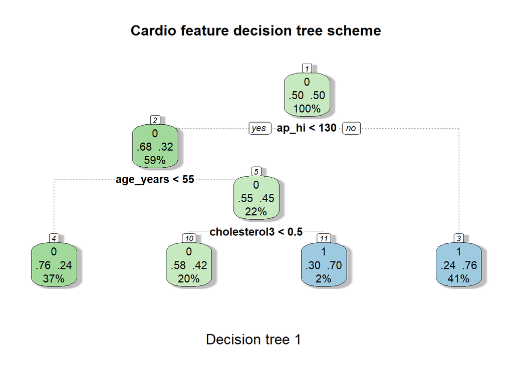

```r
library(rattle)
fancyRpartPlot(fit$finalModel,main="Cardio feature decision tree scheme",sub="Decision tree 1")
```

**What is the accuracy of prediction on test data?**

```r
pred<-predict(fit, test)
acc<-sum(pred==test$cardio)/nrow(test)
print(acc)
```

```
## [1] 0.7257012
```

**Now set cross validation parameters: `method = "cv"`, `number = 5`. Tree parameters set to default.**

```r
fitControl<-trainControl(method ="cv",number=5)
fit2<-train(cardio~gender+height+weight+ap_hi+ap_lo+cholesterol+gluc+smoke+alco+active+age_years, data=training,method="rpart",trControl=fitControl)
```

**Plot final tree with `rattle` library**

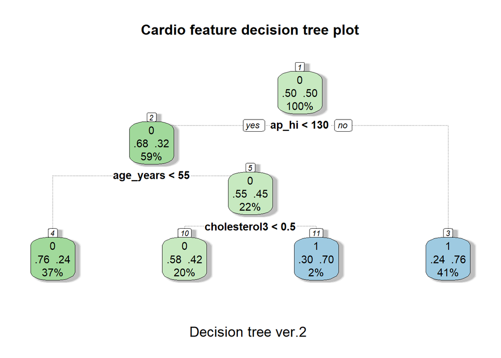

```r
library(rattle)
fancyRpartPlot(fit2$finalModel,main="Cardio feature decision tree plot",sub="Decision tree ver.2")
```

**What is the accuracy of prediction on test data?**

```r
newPred<-predict(fit2,test)
acc<-sum(newPred==test$cardio)/nrow(test)
print(acc)
```

```
## [1] 0.7257012
```

**Does the accuracy became better or not?**

**R:** Changing model parameters didn’t improve its accuracy.